# PSL (F20) Project 1

Vijayakumar Sitha Mohan (VS24), Waitong Matthew Leung (wmleung2)

#### Introduction

The goal is to predict the final price of a home (in log scale) using AMES housing dataset. As a project requirement we need to build Two prediction models and we chose Lasso/Ridge Regression and XBGBoost as our model to predict the sale price.

#### Data Exploration

The dataset has 2930 rows (i.e., houses) and 83 columns.The first column is “PID”, the Parcel identification number; The last column is the response variable, Sale_Price;The remaining 81 columns are explanatory variables describing (almost) every aspect of residential homes.

- Analysis of Response Variable(Sale Price) A mean and median sale price of $180,796 and $160,000 respectively, indicating a positive skew, which was confirmed by
- Histogram of the Sale Price. A long right tail tells that there are outlier data points. max = 755,000 and min = 12,789
- Skewness also in quite a few variables

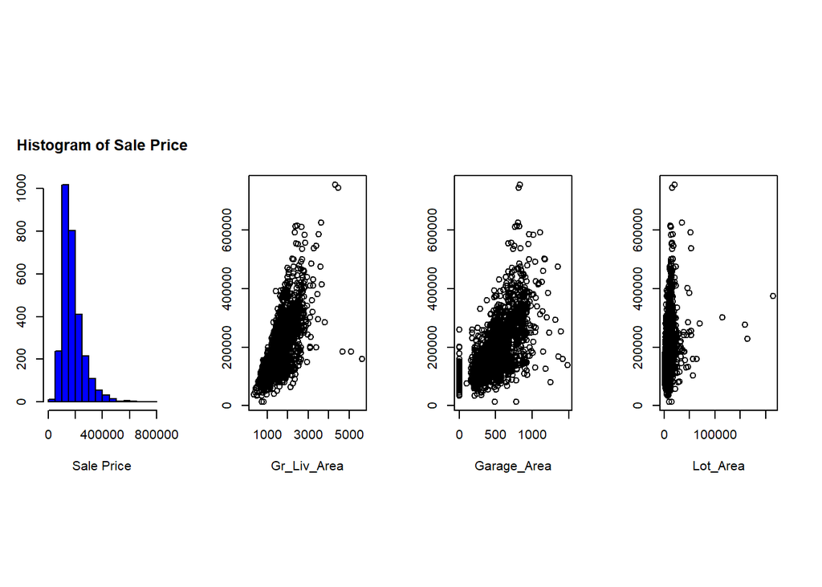

#### Overall Approach

We chose the following two models to tackle this home price prediction problem. The general approach of both of the models are in the sequence of data prepreprocessing, optimal hyperparameters search, train model based on train data set and finally predict sale price with test data set.

- Model 1: Lasso and Ridge mixed model. We use Lasso 10-fold cross validation to select relevant variables and lambda value first. Subsequently, We use selected variables and lambda value from Lasso to train Ridge model in order to remove colinearity of remaining variables.
- Model 2: XGBoost model. We spent quite a lot of time (~16 hours) to search for the optimal value for the following hyperparameters, namely eta, max_depth, subsample. We randomly generated 10,000 combination of the three hyperparameters to select the set that give us minimal RMSE.

#### Model 1: LASSO/Ridge Regression Model

- Lasso 10 Fold Cross Validation to choose Lamda hyperparameter
- Lasso Feature Engineering to select variables with non zero coefficients
- Ridge Fit & Predict using optimal hyperparameters

#### Model 2: XGBoost - Boosting Model

- Train model to choose eta, subsample, max_depth hyperparameter: Ran model selection by running 10000 times and chose the lowest test rmse and corresponding hyperparameter values. Run time was around ~16 hours
- Optimal hyperparameters: (eta = 0.0474239, max_depth = 4, subsample = 0.541795)
- Fit & Predict using optimal hyperparameters

#### Results

| Split # | Lasso Test Error | XGBoost Test Error |
| --- | --- | --- |
| 1 | 0.1149 | 0.0694 |
| 2 | 0.1203 | 0.0724 |
| 3 | 0.1130 | 0.0653 |
| 4 | 0.1204 | 0.1173 |
| 5 | 0.1086 | 0.0704 |
| 6 | 0.1292 | 0.0694 |
| 7 | 0.1345 | 0.0724 |
| 8 | 0.1280 | 0.0653 |
| 9 | 0.1340 | 0.1168 |
| 10 | 0.1241 | 0.0704 |

- Mean Train & Test Error for Lasso & XGBoost Model

| lasso.train.error | lasso.test.error | xgboost.train.error | xgboost.test.error |
| --- | --- | --- | --- |
| 0.1019 | 0.1227 | 0.0616 | 0.0789 |

- Running time: System: MSI laptop, Intel i7, 2.60GHz, 16GB, Win 10

| Lasso total train & test time (second) | XGBoost total train & test time (second) |
| --- | --- |
| 5.712 | 6.013 |